# 데이터_탐색과_시각화

```python
! jupyter nbconvert --to markdown 데이터_탐색과_시각화.ipynb
```

```
[NbConvertApp] Converting notebook 데이터_탐색과_시각화.ipynb to markdown
[NbConvertApp] Support files will be in 데이터_탐색과_시각화_files\
[NbConvertApp] Making directory 데이터_탐색과_시각화_files
[NbConvertApp] Writing 27946 bytes to 데이터_탐색과_시각화.md
```

> - EDA(Exploratory Data Analysis 탐색적 데이터 분석)와 데이터 시각화의 목적은 조금 다르다.
- DEA 단계에서 데이터 파악을 효율적으로 하기 위해 시각화를 하기도 하지만, 데이터 시각화의 궁극적인 목적은 분석 결과를 커뮤니케이션 하기 위함이다.
- **시각화의 유형**
1. 시간의 흐름에 따른 변화 -> 시간 시각화
2. 그룹별 차이 -> 비교 시각화
3. 전체 data에서 특정 항목의 비중 -> 분포 시각화
4. 2개 이상의 수치 data 간의 관계 -> 관계 시각화
5. 지리적 위치에 수치 표기 -> 공간 시각화

## **1. 탐색적 data 분석**

- EDA를 할 때에는 극단적인 해석, 지나친 추론, 자의적 해석을 지양해야 한다.

> **가장 간단하면서도 효과적인 방법 : 1000개의 data sample과 변수와 설명 list를 눈으로 보기**
- 논리적으로 잘못된 부분을 찾아내고, 해당 이슈가 발생할 수 있는 case를 고밍해본다.

```python
# 필요한 패키지 임포트
import seaborn as sns
import matplotlib.pyplot as plt
import pandas as pd
sns.set(color_codes = True)
%matplotlib inline
```

```python
# 데이터 불러오기
df = pd.read_csv("/content/drive/MyDrive/KHUDA 동아리/datasest/hotel_bookings.csv")

# 데이터 샘플 확인
df.head()
```

|  | hotel | is_canceled | lead_time | arrival_date_year | arrival_date_month | arrival_date_week_number | arrival_date_day_of_month | stays_in_weekend_nights | stays_in_week_nights | adults | ... | deposit_type | agent | company | days_in_waiting_list | customer_type | adr | required_car_parking_spaces | total_of_special_requests | reservation_status | reservation_status_date |
| --- | --- | --- | --- | --- | --- | --- | --- | --- | --- | --- | --- | --- | --- | --- | --- | --- | --- | --- | --- | --- | --- |
| 0 | Resort Hotel | 0 | 342 | 2015 | July | 27 | 1 | 0 | 0 | 2 | ... | No Deposit | NaN | NaN | 0 | Transient | 0.0 | 0 | 0 | Check-Out | 2015-07-01 |
| 1 | Resort Hotel | 0 | 737 | 2015 | July | 27 | 1 | 0 | 0 | 2 | ... | No Deposit | NaN | NaN | 0 | Transient | 0.0 | 0 | 0 | Check-Out | 2015-07-01 |
| 2 | Resort Hotel | 0 | 7 | 2015 | July | 27 | 1 | 0 | 1 | 1 | ... | No Deposit | NaN | NaN | 0 | Transient | 75.0 | 0 | 0 | Check-Out | 2015-07-02 |
| 3 | Resort Hotel | 0 | 13 | 2015 | July | 27 | 1 | 0 | 1 | 1 | ... | No Deposit | 304.0 | NaN | 0 | Transient | 75.0 | 0 | 0 | Check-Out | 2015-07-02 |
| 4 | Resort Hotel | 0 | 14 | 2015 | July | 27 | 1 | 0 | 2 | 2 | ... | No Deposit | 240.0 | NaN | 0 | Transient | 98.0 | 0 | 1 | Check-Out | 2015-07-03 |

5 rows × 32 columns

```python
df.info()
# 숫자형으로 되어야 하는 column이 문자형으로 되어있을 수도 있기에, 자료형을 확인
# 결측값 확인
```

```
<class 'pandas.core.frame.DataFrame'>
RangeIndex: 119390 entries, 0 to 119389
Data columns (total 32 columns):
 #   Column                          Non-Null Count   Dtype
---  ------                          --------------   -----
 0   hotel                           119390 non-null  object
 1   is_canceled                     119390 non-null  int64
 2   lead_time                       119390 non-null  int64
 3   arrival_date_year               119390 non-null  int64
 4   arrival_date_month              119390 non-null  object
 5   arrival_date_week_number        119390 non-null  int64
 6   arrival_date_day_of_month       119390 non-null  int64
 7   stays_in_weekend_nights         119390 non-null  int64
 8   stays_in_week_nights            119390 non-null  int64
 9   adults                          119390 non-null  int64
```

[output cut: 24 more lines]

```python
# 기술 통게
df.describe()
```

|  | is_canceled | lead_time | arrival_date_year | arrival_date_week_number | arrival_date_day_of_month | stays_in_weekend_nights | stays_in_week_nights | adults | children | babies | is_repeated_guest | previous_cancellations | previous_bookings_not_canceled | booking_changes | agent | company | days_in_waiting_list | adr | required_car_parking_spaces | total_of_special_requests |
| --- | --- | --- | --- | --- | --- | --- | --- | --- | --- | --- | --- | --- | --- | --- | --- | --- | --- | --- | --- | --- |
| count | 119390.000000 | 119390.000000 | 119390.000000 | 119390.000000 | 119390.000000 | 119390.000000 | 119390.000000 | 119390.000000 | 119386.000000 | 119390.000000 | 119390.000000 | 119390.000000 | 119390.000000 | 119390.000000 | 103050.000000 | 6797.000000 | 119390.000000 | 119390.000000 | 119390.000000 | 119390.000000 |
| mean | 0.370416 | 104.011416 | 2016.156554 | 27.165173 | 15.798241 | 0.927599 | 2.500302 | 1.856403 | 0.103890 | 0.007949 | 0.031912 | 0.087118 | 0.137097 | 0.221124 | 86.693382 | 189.266735 | 2.321149 | 101.831122 | 0.062518 | 0.571363 |
| std | 0.482918 | 106.863097 | 0.707476 | 13.605138 | 8.780829 | 0.998613 | 1.908286 | 0.579261 | 0.398561 | 0.097436 | 0.175767 | 0.844336 | 1.497437 | 0.652306 | 110.774548 | 131.655015 | 17.594721 | 50.535790 | 0.245291 | 0.792798 |
| min | 0.000000 | 0.000000 | 2015.000000 | 1.000000 | 1.000000 | 0.000000 | 0.000000 | 0.000000 | 0.000000 | 0.000000 | 0.000000 | 0.000000 | 0.000000 | 0.000000 | 1.000000 | 6.000000 | 0.000000 | -6.380000 | 0.000000 | 0.000000 |
| 25% | 0.000000 | 18.000000 | 2016.000000 | 16.000000 | 8.000000 | 0.000000 | 1.000000 | 2.000000 | 0.000000 | 0.000000 | 0.000000 | 0.000000 | 0.000000 | 0.000000 | 9.000000 | 62.000000 | 0.000000 | 69.290000 | 0.000000 | 0.000000 |
| 50% | 0.000000 | 69.000000 | 2016.000000 | 28.000000 | 16.000000 | 1.000000 | 2.000000 | 2.000000 | 0.000000 | 0.000000 | 0.000000 | 0.000000 | 0.000000 | 0.000000 | 14.000000 | 179.000000 | 0.000000 | 94.575000 | 0.000000 | 0.000000 |
| 75% | 1.000000 | 160.000000 | 2017.000000 | 38.000000 | 23.000000 | 2.000000 | 3.000000 | 2.000000 | 0.000000 | 0.000000 | 0.000000 | 0.000000 | 0.000000 | 0.000000 | 229.000000 | 270.000000 | 0.000000 | 126.000000 | 0.000000 | 1.000000 |
| max | 1.000000 | 737.000000 | 2017.000000 | 53.000000 | 31.000000 | 19.000000 | 50.000000 | 55.000000 | 10.000000 | 10.000000 | 1.000000 | 26.000000 | 72.000000 | 21.000000 | 535.000000 | 543.000000 | 391.000000 | 5400.000000 | 8.000000 | 5.000000 |

> **숫자형이지만, 문자형과 다름 없는 arrival_date_year와 같은 column들에 주의하자.**

```python
# 각 column의 첨도 확인
# babies와 같이 분포가 넓지 않은 column의 첨도가 매우 높게 나오는 것을 알 수 있다.
df.select_dtypes(include='number').kurtosis()
```

```
is_canceled                         -1.712005
lead_time                            1.696449
arrival_date_year                   -0.994564
arrival_date_week_number            -0.986077
arrival_date_day_of_month           -1.187168
stays_in_weekend_nights              7.174066
stays_in_week_nights                24.284555
adults                            1352.115116
children                            18.673692
babies                            1633.948235
is_repeated_guest                   26.370077
previous_cancellations             674.073693
previous_bookings_not_canceled     767.245210
booking_changes                     79.393605
agent                               -0.007180
company                             -0.490795
days_in_waiting_list               186.793070
adr                               1013.189851
required_car_parking_spaces         29.998056
total_of_special_requests            1.492565
dtype: float64
```

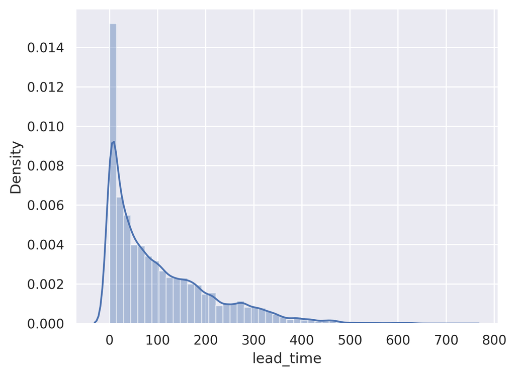

```python
# 특정 변수 분포 시각화
plt.rcParams['figure.dpi'] = 300
sns.distplot(df['lead_time'])
# 0값이 유독 많은데, 실제 당일 예약이 많은 것인지, 시스템 상 기록이 제대로 남지 않은 건을 모두 0으로 입력했는 지 확인 필요
```

```python
df['hotel'].value_counts()
```

```
hotel
City Hotel      79330
Resort Hotel    40060
Name: count, dtype: int64
```

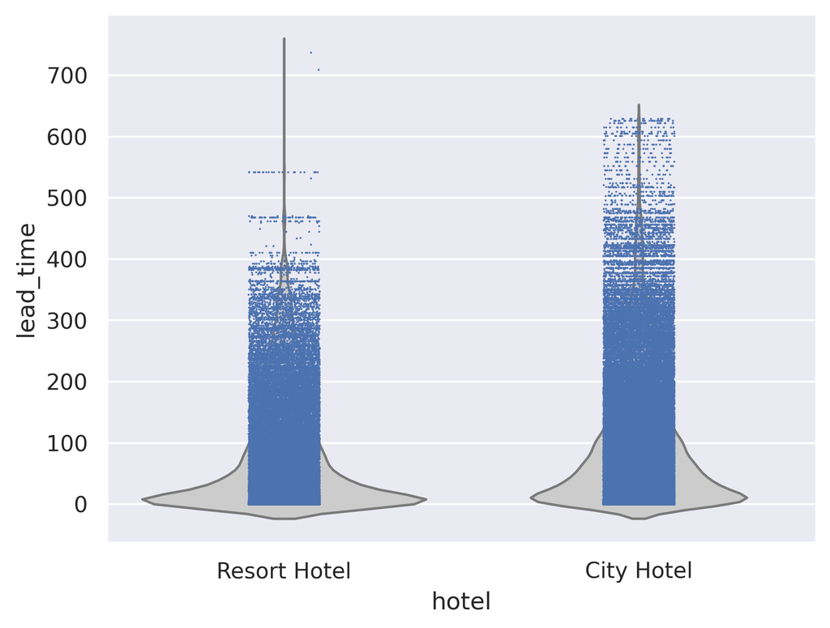

```python
# 호텔 구분에 따른 투숙객의 리드 타임 분포 차이 시각화
sns.violinplot(x = 'hotel', y = 'lead_time', data = df, inner = None, color = ".8")
sns.stripplot(x="hotel", y="lead_time", data=df, size=1)
```

```python
!jupyter nbconvert --to HTML "/content/drive/MyDrive/KHUDA 동아리/ML 세션/데이터 탐색과 시각화.ipynb"
```

```
[NbConvertApp] Converting notebook /content/drive/MyDrive/KHUDA 동아리/ML 세션/데이터 탐색과 시각화.ipynb to HTML
[NbConvertApp] Writing 962574 bytes to /content/drive/MyDrive/KHUDA 동아리/ML 세션/데이터 탐색과 시각화.html
```